# Tema 9 - Aproximación de valores y vectores propios.

## Descomposición en valores singulares

## Introducción

La **descomposición en valores singulares** consiste en **descomponer** una matriz \(\mathbf{A}\) de dimensiones \(m\times n\), no necesariamente cuadrada en tres matrices de la forma siguiente: \[ \mathbf{A}=\mathbf{U}\mathbf{D}\mathbf{V}^\top, \] donde

- \(\mathbf{U}\) es una matriz **ortogonal** (\(\mathbf{U}^\top =\mathbf{U}^{-1}\)) de dimensiones \(m\times m\),
- \(\mathbf{D}=(d_{ij})_{i=1,\ldots,m,j=1,\ldots,n}\) es una matriz **diagonal** de dimensiones \(m\times n\), es decir, que si \(i\neq j\), \(d_{ij}=0\) y
- \(\mathbf{V}\) es una matriz **ortogonal** (\(\mathbf{V}^\top =\mathbf{V}^{-1}\)) de dimensiones \(n\times n\).

## Introducción

La **descomposición de valores singulares** de una matriz es una herramienta fundamental en **análisis de datos** y **aprendizaje estadístico**.

Las aplicaciones que se derivan de dicha descomposición van desde desde **regresión a predicción**, hasta encontrar **soluciones aproximadas** a problemas de **optimización**.

Veamos cómo funciona dicha aplicación en **análisis de datos**.

Consideremos una matriz \(\mathbf{A}\) no necesariamente cuadrada de dimensiones \(m\times n\) donde las \(m\) filas serían los individuos y las \(n\) columnas representarían las variables que consideramos sobre dichos individuos.

## Introducción

Cada individuo sería un vector en el espacio \(\mathbb{R}^n\).

Imaginemos que queremos representar dichos individuos en un **espacio de dimensión menor** \(k<n\).

Para hacerlo, podemos considerar una **aproximación** de la **descomposición en valores singulares** de la matriz \(\mathbf{A}\), de la forma siguiente: \[ \tilde{\mathbf{A}}=\mathbf{U}_{m\times m}\tilde{\mathbf{D}}_{m\times k}\tilde{\mathbf{V}}_{k\times k}^\top, \] donde

- \(\tilde{\mathbf{D}}\) sería una aproximación de la matriz diagonal \(\mathbf{D}\) de dimensiones \(m\times k\) considerando sólo las \(k\) primeras columnas y
- \(\tilde{\mathbf{V}}^\top\) sería una aproximación de la matriz ortogonal \(\mathbf{V}^\top\) considerando sólo la submatriz formada por las \(k\) primeras filas y las \(k\) primeras columnas.

## Introducción

De esta forma, obtenemos una matriz \(\tilde{\mathbf{A}}\) de dimensiones \(m\times k\) con \(k\) variables que sería una aproximación o una proyección de los datos origionales sobre un espacio menor de dimensión menor \(\mathbb{R}^k\).

## Conceptos previos

Para entender el algoritmo de **descomposición en valores singulares** y trabajar con matrices no necesariamente **cuadradas**, necesitamos los conceptos previos siguientes:

Definición del rango y núcleo de una matriz \(\mathbf{A}\)

Sea \(\mathbf{A}\) una matriz \(m\times n\), entonces:

- el **rango** de la matriz \(\mathbf{A}\) es el número de **filas** o **columnas** linealmente independientes.
- el **núcleo** de la matriz \(\mathbf{A}\), denotado por \(\mathrm{Ker}(\mathbf{A})\) es el espacio vectorial siguiente: \[ \mathrm{Ker}(\mathbf{A})=\{\mathbf{x}\in\mathbb{R}^n,\ |\ \mathbf{A}\mathbf{x}=\mathbf{0}\}. \]

Observación:

La **dimensión del núcleo** de una matriz \(\mathbf{A}\) vale \(\mathrm{dim}(\mathrm{Ker}(\mathbf{A}))=n-\mathrm{Rango}(\mathbf{A}).\)

## Resultados previos

Recordemos los resultados siguientes de álgebra lineal:

Teorema.

Sea \(\mathbf{A}\) una matriz \(m\times n\). Entonces:

1. Las matrices \(\mathbf{A}^\top\mathbf{A}\) de dimensión \(n\times n\) y \(\mathbf{A}\mathbf{A}^\top\) de dimensión \(m\times m\) son simétricas.
2. El núcleo de la matriz \(\mathbf{A}\) coincide con el núcleo de la matriz \(\mathbf{A}^\top\mathbf{A}\): \(\mathrm{Ker}(\mathbf{A})=\mathrm{Ker}(\mathbf{A}^\top\mathbf{A})\).
3. El rango de la matriz \(\mathbf{A}\) coincide con el rango de la matriz \(\mathbf{A}^\top\mathbf{A}\).
4. Los valores propios de la matriz \(\mathbf{A}^\top\mathbf{A}\) son reales y no negativos.
5. Los valores propios no nulos de la matriz \(\mathbf{A}^\top\mathbf{A}\) son los mismos que los valores propios no nulos de la matriz \(\mathbf{A}\mathbf{A}^\top\).

## Demostración del Teorema

1. La matriz \(\mathbf{A}^\top\mathbf{A}\) es simétrica porque coincide con su traspuesta: \((\mathbf{A}^\top\mathbf{A})^\top =\mathbf{A}^\top(\mathbf{A}^\top)^\top =\mathbf{A}^\top\mathbf{A}\).

   La simetría de la matriz \(\mathbf{A}\mathbf{A}^\top\) se demuestra de forma idéntica.
2. Veamos primero que \(\mathrm{Ker}(\mathbf{A})\subseteq\mathrm{Ker}(\mathbf{A}^\top\mathbf{A})\): sea \(\mathbf{x}\in\mathrm{Ker}(\mathbf{A})\), entonces \(\mathbf{A}\mathbf{x}=\mathbf{0}\).

   Por tanto, \(\mathbf{A}^\top\mathbf{A}\mathbf{x}=\mathbf{A}^\top(\mathbf{A}\mathbf{x})=\mathbf{A}^\top\mathbf{0}=\mathbf{0}\), lo que significa que \(\mathbf{x}\in\mathrm{Ker}(\mathbf{A}^\top\mathbf{A})\).

   Veamos ahora que \(\mathrm{Ker}(\mathbf{A}^\top\mathbf{A})\subseteq\mathrm{Ker}(\mathbf{A})\). Sea \(\mathbf{x}\in \mathrm{Ker}(\mathbf{A}^\top\mathbf{A})\), es decir \(\mathbf{A}^\top\mathbf{A}\mathbf{x}=\mathbf{0}\).

   En este caso \(\mathbf{x}^\top\mathbf{A}^\top\mathbf{A}\mathbf{x}=\mathbf{x}^\top\mathbf{0}=0=\|\mathbf{A}\mathbf{x}\|_2^2\).

   Por tanto, \(\mathbf{A}\mathbf{x}=\mathbf{0}\) al ser \(\|\cdot\|_2\) norma vectorial, lo que significa que \(\mathbf{x}\in\mathrm{Ker}(\mathbf{A})\).
3. \(\mathrm{Rango}(\mathbf{A})=n-\mathrm{dim}(\mathrm{Ker}(\mathbf{A}))=n-\mathrm{dim}(\mathrm{Ker}(\mathbf{A}^\top\mathbf{A}))=\mathrm{Rango}(\mathbf{A}^\top\mathbf{A})\).

## Demostración del Teorema

4. Al ser la matriz \(\mathbf{A}^\top\mathbf{A}\) simétrica, sus valores propios serán reales.

   Además, dado un vector \(\mathbf{x}\in\mathbb{R}^n\), tenemos que \(\mathbf{x}^\top\mathbf{A}^\top\mathbf{A}\mathbf{x}=\|\mathbf{A}\mathbf{x}\|_2^2\geq 0\). Es decir, la matriz \(\mathbf{A}^\top\mathbf{A}\) es definida positiva.
5. Sea \(\lambda\neq 0\) un valor propio no nulo de la matriz \(\mathbf{A}^\top\mathbf{A}\).

   Entonces, existe un vector propio \(\mathbf{x}\in\mathbb{R}^n\) tal que \(\mathbf{A}^\top\mathbf{A}\mathbf{x}=\lambda\mathbf{x}\).

   Multiplicando por \(\mathbf{A}\) la igualdad anterior tenemos que \(\mathbf{A}\mathbf{A}^\top\mathbf{A}\mathbf{x}=\lambda\mathbf{A}\mathbf{x}\), es decir, el vector \(\mathbf{A}\mathbf{x}\) es un vector propio de valor propio \(\lambda\) de la matriz \(\mathbf{A}\mathbf{A}^\top\).

   El valor \(\mathbf{A}\mathbf{x}\neq\mathbf{0}\) ya que en caso contrario, \(\mathbf{A}\mathbf{x}=\mathbf{0}\), y por tanto, \(\mathbf{x}\) sería un vector propio de \(\mathbf{A}\) de valor propio \(\lambda=0\) y habíamos supuesto \(\lambda\neq 0\).

   Supongamos ahora que \(\lambda\neq 0\) es un valor propio no nulo de la matriz \(\mathbf{A}\mathbf{A}^\top =(\mathbf{A}^\top)^\top\mathbf{A}^\top\). Aplicando el razonamiento anterior cambiando los papeles de las matrices \(\mathbf{A}^\top\) y \(\mathbf{A}\), tendremos que \(\lambda\) será un valor propio no nulo de la matriz \(\mathbf{A}^\top(\mathbf{A}^\top)^\top =\mathbf{A}^\top\mathbf{A}\), tal como queríamos ver.

## Algoritmo

Dada una matriz \(\mathbf{A}\) de dimensiones \(m\times n\), es decir, con \(m\) filas y \(n\) columnas, veamos cómo hallar las matrices \(\mathbf{U}\), \(m\times m\), \(\mathbf{D}\), \(m\times n\) y \(\mathbf{V}\), \(n\times n\), tal que \(\mathbf{A}=\mathbf{U}\mathbf{D}\mathbf{V}^\top\):

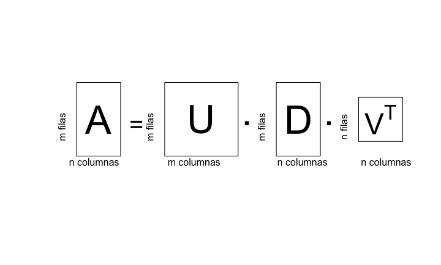

## Algoritmo

- Paso \(1\). Los valores **diagonales** de la matriz \(\mathbf{D}\) de dimensiones \(m\times n\) están formados por las raíces cuadradas de los **valores propios** no negativos \(\lambda_i\), \(i=1,\ldots,n\), escritos en forma decreciente de la matriz \(\mathbf{A}^\top\mathbf{A}\) de dimensiones \(n\times n\), \(\lambda_1\geq \lambda_2\geq\cdots\geq \lambda_k >0=\lambda_{k+1}=\cdots =\lambda_n=0\). Recordemos que dichos valores propios son no negativos ya que la matriz \(\mathbf{A}^\top\mathbf{A}\) es definida positiva.

\[ \mathbf{D}=\begin{bmatrix}\sqrt{\lambda_{1}}&0&\ldots&0&0&\ldots&0 \\0&\sqrt{\lambda_{2}}&\ldots&0&0&\ldots&0 \\\vdots&\vdots&\ddots&\vdots&\vdots&\vdots&\vdots \\0&\ldots&0&\sqrt{\lambda_{k}}&0&\ldots&0 \\0&\ldots&0&0&0&\ldots&0 \\\vdots&\vdots&\vdots&\vdots&\vdots&\ddots&\vdots \\0&\ldots&0&0&0&\ldots&0 \\\end{bmatrix}. \]

## Algoritmo

- Paso \(2\). Al ser la matriz \(\mathbf{A}^\top\mathbf{A}\) **simètrica**, existe una base **ortogonal** de **vectores propios** para cada **valor propio** \(\lambda_i\), \(i=1\ldots,n\). Sea \(\mathbf{v}^{(i)}\) un **vector propio** de la matriz \(\mathbf{A}^\top\mathbf{A}\) de **valor propio** \(\lambda_i\), \(i=1,\ldots,n\), donde suponemos que \((\mathbf{v}^{(i)})^\top \mathbf{v}^{(j)}=0\), si \(i\neq j\) y \((\mathbf{v}^{(i)})^\top \mathbf{v}^{(i)}=1\), para \(i=\ldots,n\). Entonces la matriz **ortogonal** \(\mathbf{V}\) tiene como columnas los vectores propios anteriores \(\mathbf{v}^{(i)}\): \[ \mathbf{V}=\begin{bmatrix}\mathbf{v}^{(1)} & \cdots & \mathbf{v}^{(n)}\end{bmatrix}. \]

## Algoritmo

- Paso \(3\). Para construir la matriz \(\mathbf{U}\) consideremos sólo los **valores propios** \(\lambda_i\) de la matriz \(\mathbf{A}^\top\mathbf{A}\) no nulos: \(\lambda_1 \geq \lambda_2\geq\cdots\geq \lambda_k\). Definimos: \[ \mathbf{u}^{(i)}=\frac{1}{\sqrt{\lambda_i}}\mathbf{A}\mathbf{v}^{(i)}, \] para \(i=1,\ldots,k\).

Los vectores anteriores son ortogonales ya que: \[ \begin{align*} (\mathbf{u}^{(i)})^\top \mathbf{u}^{(j)} & =\left(\frac{1}{\sqrt{\lambda_i}}\mathbf{A}\mathbf{v}^{(i)}\right)^\top \frac{1}{\sqrt{\lambda_j}}\mathbf{A}\mathbf{v}^{(j)}=\frac{1}{\sqrt{\lambda_i\lambda_j}}(\mathbf{v}^{(i)})^\top\mathbf{A}^\top\mathbf{A}\mathbf{v}^{(j)}\\ & =\frac{1}{\sqrt{\lambda_i\lambda_j}}(\mathbf{v}^{(i)})^\top\lambda_j\mathbf{v}^{(j)}=\frac{\lambda_j}{\sqrt{\lambda_i\lambda_j}}(\mathbf{v}^{(i)})^\top \mathbf{v}^{(j)}=\begin{cases}0, & \mathrm{si\ }i\neq j,\\ 1,&\mathrm{si\ }i=j.\end{cases} \end{align*} \]

## Algoritmo

- Paso \(3\) (continuación). La matriz \(\mathbf{U}\) tiene dimensiones \(m\times m\). Observemos que \(m\geq k\), ya que: \[ m\geq \min\{m,n\}\geq \mathrm{Rango}(\mathbf{A})=\mathrm{Rango}(\mathbf{A}^\top\mathbf{A})=k. \] Las primeras **\(k\) columnas** de la matriz \(\mathbf{U}\) están formadas por los vectores \(\mathbf{u}^{(i)}\), \(i=1,\ldots,k\). Como veremos más adelante, las \(m-k\) columnas restantes no intervienen para nada en la **descomposición en valores singulares**.

## Algoritmo

- Paso \(3\) (continuación). Por tanto, no hace falta calcularlas. Si por “estética”, queremos una matriz \(\mathbf{U}\) de dimensiones \(m\times m\) **ortogonal**, podemos considerar \(m-k\) **vectores linealmente independientes** \(\mathbf{\tilde{u}}^{(k+1)},\ldots,\mathbf{\tilde{u}}^{(m)}\) de tal forma que los vectores \(\mathbf{u}^{(1)},\ldots,\mathbf{u}^{(k)},\mathbf{\tilde{u}}^{(k+1)},\ldots,\mathbf{\tilde{u}}^{(m)}\) formen una **base** del espacio \(\mathbb{R}^m\) y aplicando el **método de ortogonalización de Gram-Schmidt** visto en el capítulo de **resolución de sistemas de ecuaciones para métodos directos** podríamos hallar una base ortogonal de \(\mathbb{R}^m\) de la forma: \(\mathbf{u}^{(1)},\ldots,\mathbf{u}^{(k)},\mathbf{u}^{(k+1)},\ldots,\mathbf{u}^{(m)}\). La matriz \(\mathbf{U}\) será aquella matriz cuyas columnas son los vectores anteriores: \[ \mathbf{U}=\begin{bmatrix}\mathbf{u}^{(1)} & \cdots &\mathbf{u}^{(k)}&\mathbf{u}^{(k+1)}&\cdots & \mathbf{u}^{(m)}\end{bmatrix}. \] Pero, como ya hemos indicado antes, todo este trabajo no es necesario de cara a hallar la **descomposición en valores singulares**.

## Demostración de \(\mathbf{A}=\mathbf{U}\mathbf{D}\mathbf{V}^\top\)

Veamos que si aplicamos el algoritmo anterior, se cumple la descomposición de la matriz \(\mathbf{A}\) en **valores singulares**.

Sea \(k\) el número de **valores propios** no nulos de la matriz \(\mathbf{A}^\top\mathbf{A}\). Las **raíces cuadradas** de dichos **valores propios** se denominan **valores singulares** de la matriz \(\mathbf{A}\).

Recordemos que:

- \(\lambda_1 \geq \lambda_2\geq\cdots\geq \lambda_k > 0=\lambda_{k+1}=\cdots = \lambda_n.\)
- \(\mathbf{A}\mathbf{v}^{(i)}=\sqrt{\lambda_i}\mathbf{u}^{(i)}\), para \(i=1,\ldots,k\), y \(\mathbf{A}\mathbf{v}^{(i)}=0\), para \(i=k+1,\ldots,n\).

## Demostración de \(\mathbf{A}=\mathbf{U}\mathbf{D}\mathbf{V}^\top\)

Entonces: \[ \begin{align*} \mathbf{A}\mathbf{V} & =\mathbf{A}\begin{bmatrix}\mathbf{v}^{(1)}&\cdots &\mathbf{v}^{(k)}&\mathbf{v}^{(k+1)}&\cdots &\mathbf{v}^{(n)}\end{bmatrix} \\ & = \begin{bmatrix}\mathbf{A}\mathbf{v}^{(1)}&\cdots &\mathbf{A}\mathbf{v}^{(k)}&\mathbf{0}&\cdots &\mathbf{0}\end{bmatrix}=\begin{bmatrix}\sqrt{\lambda_1}\mathbf{u}^{(1)}&\cdots &\sqrt{\lambda_k}\mathbf{u}^{(k)}&\mathbf{0}&\cdots &\mathbf{0}\end{bmatrix}\\ & = \begin{bmatrix}\mathbf{u}^{(1)}&\cdots &\mathbf{u}^{(k)}&\mathbf{0}&\cdots &\mathbf{0}\end{bmatrix} \begin{bmatrix}\sqrt{\lambda_{1}}&0&\ldots&0&0&\ldots&0 \\0&\sqrt{\lambda_{2}}&\ldots&0&0&\ldots&0 \\\vdots&\vdots&\ddots&\vdots&\vdots&\vdots&\vdots \\0&\ldots&0&\sqrt{\lambda_{k}}&0&\ldots&0 \\0&\ldots&0&0&0&\ldots&0 \\\vdots&\vdots&\vdots&\vdots&\vdots&\ddots&\vdots \\0&\ldots&0&0&0&\ldots&0 \\\end{bmatrix}. \end{align*} \]

## Demostración de \(\mathbf{A}=\mathbf{U}\mathbf{D}\mathbf{V}^\top\)

Fijémonos que la igualdad anterior sigue siendo cierta si cambiamos las columnas nulas de la matriz \(\begin{bmatrix}\mathbf{u}^{(1)}&\cdots &\mathbf{u}^{(k)}&\mathbf{0}&\cdots &\mathbf{0}\end{bmatrix}\) por la matriz \(\mathbf{U}=\begin{bmatrix}\mathbf{u}^{(1)}&\cdots &\mathbf{u}^{(k)}&\mathbf{u}^{(k+1)}&\cdots &\mathbf{u}^{(m)}\end{bmatrix}\): \[ \mathbf{A}\mathbf{V}=\begin{bmatrix}\mathbf{u}^{(1)}&\cdots &\mathbf{u}^{(k)}&\mathbf{u}^{(k+1)}&\cdots &\mathbf{u}^{(m)}\end{bmatrix}\begin{bmatrix}\sqrt{\lambda_{1}}&0&\ldots&0&0&\ldots&0 \\0&\sqrt{\lambda_{2}}&\ldots&0&0&\ldots&0 \\\vdots&\vdots&\ddots&\vdots&\vdots&\vdots&\vdots \\0&\ldots&0&\sqrt{\lambda_{k}}&0&\ldots&0 \\0&\ldots&0&0&0&\ldots&0 \\\vdots&\vdots&\vdots&\vdots&\vdots&\ddots&\vdots \\0&\ldots&0&0&0&\ldots&0 \\\end{bmatrix}=\mathbf{U}\mathbf{D}. \] Multiplicando por \(\mathbf{V}^{-1}=\mathbf{V}^\top\), tenemos la **descomposición en valores singulares** de la matriz \(\mathbf{A}\): \[ \mathbf{A}=\mathbf{U}\mathbf{D}\mathbf{V}^\top. \]

## Pseudocódigo

- `INPUT matriz del sistema` \(\mathbf{A}\) (\(m\times n\)).
- `Calculamos` \(\mathbf{B}=\mathbf{A}^\top\mathbf{A}\).
- `Calculamos` \(\lambda_1 \geq \lambda_2\geq\cdots\geq \lambda_k >0=\lambda_{k+1}=\cdots =\lambda_n\) `los valores propios de la matriz` \(\mathbf{B}\) `con base de vectores propios ortogonal` \(\mathbf{v}^{(1)},\mathbf{v}^{(2)},\ldots,\mathbf{v}^{(k)},\mathbf{v}^{(k+1)},\ldots,\mathbf{v}^{(n)}\).
- `Set` \(\mathbf{D}=\mathbf{0}\). (\(m\times n\)) (Inicializamos la matriz \(\mathbf{D}\))
- `For i=1,...,k`
  - `Set` \(d_{ii}=\sqrt{\lambda_i}\). (construimos la matriz \(\mathbf{D}\))

## Pseudocódigo (continuación)

- `Set` \(\mathbf{V}=\mathbf{0}\). (\(n\times n\)) (Inicializamos la matriz \(\mathbf{V}\))
- `For i=1,...,n`
  - `Set` \(\mathbf{V}[,i]=\mathbf{v}^{(i)}\). (construimos la matriz \(\mathbf{V}\))
- `Set` \(\mathbf{U}=\mathbf{0}\). (\(m\times m\)) (Inicializamos la matriz \(\mathbf{U}\))
- `For i=1,...,k`
  - `Set` \(\mathbf{U}[,i]=\frac{1}{\sqrt{\lambda_i}}\mathbf{A}\mathbf{v}^{(i)}\) (construimos la matriz \(\mathbf{U}\))

## Ejemplo

Consideremos la matriz siguiente formada por \(m=6\) filas y \(n=4\) columnas: \[ \mathbf{A}=\begin{bmatrix}5&6&5&7 \\6&4&5&4 \\6&6&6&6 \\5&8&4&13 \\6&2&5&0 \\6&7&7&6 \\\end{bmatrix}. \]

- Paso \(1\). Calculamos los valores propios de la matriz \(\mathbf{A}^\top\mathbf{A}\): \[ \mathbf{A}^\top\mathbf{A}=\begin{bmatrix}5&6&6&5&6&6 \\6&4&6&8&2&7 \\5&5&6&4&5&7 \\7&4&6&13&0&6 \\\end{bmatrix}\begin{bmatrix}5&6&5&7 \\6&4&5&4 \\6&6&6&6 \\5&8&4&13 \\6&2&5&0 \\6&7&7&6 \\\end{bmatrix}=\begin{bmatrix}194&184&183&196 \\184&205&177&240 \\183&177&176&185 \\196&240&185&306 \\\end{bmatrix}. \]

## Ejemplo (continuación)

- Paso \(1\) (continuación). Los valores propios de la matriz anterior son los siguiente: \[ 810.9447053, 66.7909346, 3.2643601, 0. \] Sus raíces cuadradas serán: \[ 28.4770909, 8.1725721, 1.806754,0. \] La matriz \(\mathbf{D}\) será, pues: \[ \mathbf{D}=\begin{bmatrix}28.477091&0&0&0 \\0&8.172572&0&0 \\0&0&1.806754&0 \\0&0&0&0 \\0&0&0&0 \\0&0&0&0 \\\end{bmatrix}. \] Notemos que en nuestro caso \(k=3\) ya que un valor propio es nulo.

## Ejemplo (continuación)

- Paso \(2\). Los vectores propios ortogonales correspondientes a los valores propios anteriores de la matriz \(\mathbf{A}^\top\mathbf{A}\) son los siguientes: \[ \mathbf{v}^{(1)}=\begin{bmatrix}-0.465077 \\-0.500532 \\-0.44275 \\-0.580641 \\\end{bmatrix},\ \mathbf{v}^{(2)}=\begin{bmatrix}-0.507531 \\0.104327 \\-0.497351 \\0.695824 \\\end{bmatrix},\ \mathbf{v}^{(3)}=\begin{bmatrix}0.652776 \\-0.581879 \\-0.395746 \\0.280509 \\\end{bmatrix},\ \mathbf{v}^{(4)}=\begin{bmatrix}-0.316228 \\-0.632456 \\0.632456 \\0.316228 \\\end{bmatrix}. \] La matriz \(\mathbf{V}\) será, pues: \[ \mathbf{V}=\begin{bmatrix}-0.465077&-0.507531&0.652776&-0.316228 \\-0.500532&0.104327&-0.581879&-0.632456 \\-0.44275&-0.497351&-0.395746&0.632456 \\-0.580641&0.695824&0.280509&0.316228 \\\end{bmatrix}. \]

## Ejemplo (continuación)

- Paso \(3\). Calculemos las \(k=3\) primeras columnas de la matriz \(\mathbf{U}\): \[ \begin{align*} \mathbf{u}^{(1)} & =\frac{1}{\sqrt{\lambda_1}}\mathbf{A}\mathbf{v}^{(1)}=\frac{1}{28.477091}\begin{bmatrix}5&6&5&7 \\6&4&5&4 \\6&6&6&6 \\5&8&4&13 \\6&2&5&0 \\6&7&7&6 \\\end{bmatrix}\begin{bmatrix}-0.465077 \\-0.500532 \\-0.44275 \\-0.580641 \\\end{bmatrix}=\begin{bmatrix}-0.407584 \\-0.327593 \\-0.419074 \\-0.549528 \\-0.210881 \\-0.452198 \\\end{bmatrix},\\ \mathbf{u}^{(2)} & =\frac{1}{\sqrt{\lambda_2}}\mathbf{A}\mathbf{v}^{(2)}=\frac{1}{8.172572}\begin{bmatrix}5&6&5&7 \\6&4&5&4 \\6&6&6&6 \\5&8&4&13 \\6&2&5&0 \\6&7&7&6 \\\end{bmatrix}\begin{bmatrix}-0.507531 \\0.104327 \\-0.497351 \\0.695824 \\\end{bmatrix}=\begin{bmatrix}0.057794 \\-0.285263 \\-0.150305 \\0.655029 \\-0.65136 \\-0.198396 \\\end{bmatrix}. \end{align*} \]

## Ejemplo (continuación)

\[ \mathbf{u}^{(3)} =\frac{1}{\sqrt{\lambda_3}}\mathbf{A}\mathbf{v}^{(3)}=\frac{1}{1.806754}\begin{bmatrix}5&6&5&7 \\6&4&5&4 \\6&6&6&6 \\5&8&4&13 \\6&2&5&0 \\6&7&7&6 \\\end{bmatrix}\begin{bmatrix}0.652776 \\-0.581879 \\-0.395746 \\0.280509 \\\end{bmatrix}=\begin{bmatrix}-0.134255 \\0.405391 \\-0.14725 \\0.3722 \\0.428484 \\-0.688345 \\\end{bmatrix}. \] Las tres primeras columnas de la matriz \(\mathbf{U}\) serían las siguientes: \[ \begin{bmatrix}-0.407584&0.057794&-0.134255 \\-0.327593&-0.285263&0.405391 \\-0.419074&-0.150305&-0.14725 \\-0.549528&0.655029&0.3722 \\-0.210881&-0.65136&0.428484 \\-0.452198&-0.198396&-0.688345 \\\end{bmatrix}. \]

## Ejemplo (continuación)

La matriz \(\mathbf{U}\) sería por tanto: \[ \mathbf{U}=\begin{bmatrix}-0.407584&0.057794&-0.134255&*&*&* \\-0.327593&-0.285263&0.405391&*&*&* \\-0.419074&-0.150305&-0.14725&*&*&* \\-0.549528&0.655029&0.3722&*&*&* \\-0.210881&-0.65136&0.428484&*&*&* \\-0.452198&-0.198396&-0.688345&*&*&* \\\end{bmatrix}. \] donde las tres últimas columnas de asteriscos se puede substituir por tres vectores que hagan que la matriz \(\mathbf{U}\) sea ortogonal pero de cara a la descomposición en valores singulares \(\mathbf{A}=\mathbf{U}\mathbf{D}\mathbf{V}^\top\) podemos substituir dichas columnas por los valores que queramos, la igualdad anterior siempre se mantendría.

Eso sí, si escribimos valores cualesquiera, la matriz \(\mathbf{U}\) ya no sería ortogonal pero se mantrendría la igualdad de descomposición en valores singulares. Basta saber que existen tres vectores \(\mathbf{u}^{(4)},\mathbf{u}^{(5)},\mathbf{u}^{(6)}\) que hacen que la matriz \(\mathbf{U}\) es ortogonal pero saber qué valen dichos vectores es irrevelante.

[figure not shown]